# Breaking Down UK Decathlon Performances

Sam Gorman

2022-12-15

## The Decathlon

Decathlon has been an olympic event since 1912 with its roots tracing back to the acient greek pentathlon. The event takes place over two days with 5 events each day. The order of events is; 100m, Long Jump, Shotput, High Jump, 400m, 110m Hurdles, Discus, Pole Vault, Javelin and 1500. It’s scored by the following formula;
$$Points = A \cdot |B-P|^C$$
Where $P$ is the performance (in centi-meters for jumps, meters for throws and seconds for track events) and $A$, $B$ and $C$ defined as follows;

| Event | A | B | C |
| --- | --- | --- | --- |
| 100m | 25.43470 | 18.0 | 1.81 |
| Long Jump | 0.14354 | 220.0 | 1.40 |
| Shotput | 51.39000 | 1.5 | 1.05 |
| High Jump | 0.84650 | 75.0 | 1.42 |
| 400m | 1.53775 | 82.0 | 1.81 |
| Hurdles | 5.74352 | 28.5 | 1.92 |
| Discus | 12.91000 | 4.0 | 1.10 |
| Pole Vault | 0.27970 | 100.0 | 1.35 |
| Javelin | 10.14000 | 7.0 | 1.08 |
| 1500 | 0.03768 | 480.0 | 1.85 |

## Getting The Data

The results for all competitions of a sufficient standard is hosted on the [power of 10](https://www.thepowerof10.info/) website. I will scrape this data using rvest.

We use the following packages:

```r
library(tidyverse)
library(rvest)
library(lubridate)
library(MASS)
library(GGally)
```

And then we collect the data using the following functions;

```r
#This simplifies the get_decathletes function
get_name = function(athletelink){
  name =  read_html(athletelink) |>
    html_elements("body") |>
    html_elements("table")
  name =  name[[6]] |>
    html_table() |>
    as.data.frame()
  return(name[1,1])
}

#Get a data frame of decathletes from a rankings page
get_decathletes = function(rankingslink){

  decyear = read_html(rankingslink) |>
    html_element(xpath='//*[@id="cphBody_lblCachedRankingList"]/table') |>
    html_table() |>
    filter(is.na(as.numeric(X1))==FALSE) |>
    dplyr::select(c("X2","X7","X11")) |>
    rename("Points"="X2","Name"="X7","Club"="X11") |>
    mutate(Firstname=word(Name,1)) |>
    mutate(Surname=word(Name,-1))

  links = read_html(rankingslink) |>
    html_elements("a") |>
    html_attr("href")

  links = data.frame(Links=links) |>
    filter(substr(Links,0,33) == "/athletes/profile.aspx?athleteid=") |>
    mutate(Links = paste0("https://www.thepowerof10.info",Links))

  for (i in 1:nrow(links)){
    try({
      name = get_name(links$Links[i])
      links$Firstname[i] = word(name,1)
      links$Surname[i] = word(name,-1)
    })
  }

  decyear = left_join(decyear,links,by=c("Firstname","Surname"))
  return(decyear)
}

#Given an athlete, get the points from their personal bests
get_points_pbs = function(athletelink){
  pbs = read_html(athletelink) |>
    html_element(xpath='//*[@id="cphBody_pnlBestPerformances"]/table[2]') |>
    html_table() |>
    as.data.frame() |>
    filter( X1 %in% c("100","LJ","SP7.26K","HJ","400",
                      "110H","DT2K","PV","JT800","1500") ==TRUE) |>
    dplyr::select(c(X1,X2))

  for (i in 1:nrow(pbs)){
    pbs$X2[i] = strsplit(pbs$X2[i],"/")[[1]][1]
    if (substr(pbs$X2[i],nchar(pbs$X2[i]),nchar(pbs$X2[i])) %in% c("i","w") == TRUE){
      pbs$X2[i] = substr(pbs$X2[i],0,nchar(pbs$X2[i])-1)
    }
    if (pbs$X1[i] == "1500"){
      pbs$X2[i] = period_to_seconds(ms(pbs$X2[i]))
    }
    if (pbs$X1[i] == "400" & is.na(as.numeric(pbs$X2[i]))==TRUE){
      pbs$X2[i] = period_to_seconds(ms(pbs$X2[i]))
    }
    if (pbs$X1[i] %in% c("LJ","HJ","PV") == TRUE){
      pbs$X2[i] = 100*as.numeric(pbs$X2[i])
    }
  }

  calcdf =  data.frame(
    Event=c("100","LJ","SP7.26K","HJ","400",
            "110H","DT2K","PV","JT800","1500"),
    A=c(25.4347,0.14354,51.39,0.8465,1.53775,
        5.74352,12.91,0.2797,10.14,0.03768),
    B=c(18,220,1.5,75,82,28.5,4,100,7,480),
    C=c(1.81,1.4,1.05,1.42,1.81,1.92,1.1,1.35,1.08,1.85))

  pbs = pbs |> left_join(calcdf, by=c("X1" = "Event")) |>
    mutate(X2 = as.numeric(X2)) |>
    mutate(points = as.integer(A*abs(B-X2)^C))

  return(pbs)
}

#Gets an athletes performances from their best decathlon in a given year
get_decathlon_perf = function(athletelink, year){

  dec = read_html(athletelink) |>
    html_element(xpath = '//*[@id="cphBody_pnlPerformances"]/table[2]') |>
    html_table()

  dec = dec |> mutate( X12 = dmy(X12)) |> na.omit() |> filter(year(X12) == year)

  maxpoints = dec$X2[which(dec$X1 == "Dec" & !is.na(as.numeric(dec$X2)))] |> strtoi() |> max()
  maxpoints = which(dec$X2 == maxpoints)[1]
  comp_name = dec$X11[maxpoints]
  comp_location = dec$X10[maxpoints]

  dec = dec |> filter(X10 == comp_location & X11 == comp_name & X1 != "Dec") |> dplyr::select(X1,X2)

  for (i in 1:nrow(dec)){
    if (dec$X1[i] == "1500"){
      dec$X2[i] = period_to_seconds(ms(dec$X2[i]))
    }
    if (dec$X1[i] == "400" & is.na(as.numeric(dec$X2[i]))==TRUE){
      dec$X2[i] = period_to_seconds(ms(dec$X2[i]))
    }
    if (dec$X1[i] %in% c("LJ","HJ","PV") == TRUE){
      dec$X2[i] = 100*as.numeric(dec$X2[i])
    }
  }


  if (nrow(dec)<10){
    allevents = c("100","LJ","SP7.26K","HJ","400","110H",
                  "DT2K","PV","JT800","1500")
    Missing = all_events[-which(dec$X1 %in% allevents)]
    for( i in Missing){
      dec[nrow(dec)+1,] = list(i,NA)
    }
  }
  calcdf =  data.frame(
    Event=c("100","LJ","SP7.26K","HJ","400","110H",
            "DT2K","PV","JT800","1500"),
    A=c(25.4347,0.14354,51.39,0.8465,1.53775,
        5.74352,12.91,0.2797,10.14,0.03768),
    B=c(18,220,1.5,75,82,28.5,4,100,7,480),
    C=c(1.81,1.4,1.05,1.42,1.81,1.92,1.1,1.35,1.08,1.85))

  dec = dec |> left_join(calcdf, by=c("X1" = "Event")) |>
    mutate(X2 = as.numeric(X2)) |>
    mutate(points = as.integer(A*abs(B-X2)^C)) |>
    arrange(X1)


  while (nrow(dec)>10){
    dupe = which(dec$X1 == dec$X1[anyDuplicated(dec$X1)])
    if (dec$X1[dupe] %in% c("HJ","LJ","PV","SP7.26K","DT2K","JT800")){
      remove = which(dec$X2 == min(dec$X2[dupe]))[1]
      dec=dec[-remove,]
    }
    if (dec$X1[dupe] %in% c("100","400","1500","110H")){
      remove = which(dec$X2 == max(dec$X2[dupe]))
      dec=dec[-remove,]
    }
  }

  return(dec)
}
```

There is a lot going on here which probably needs a bit more explanation, but this is secondary to the actual analysis. See the [rvest](https://rvest.tidyverse.org/) documentation for more info.

## What have we seen in 2022?

### Distribution of Decathletes

Lets start with the data;

```r
Decathletes_2022 = get_decathletes("https://www.thepowerof10.info/rankings/rankinglist.aspx?event=Dec&agegroup=ALL&sex=M&year=2022")

head(Decathletes_2022)
```

```
## # A tibble: 6 x 6
##   Points Name          Club                    Firstname Surname Links
##   <chr>  <chr>         <chr>                   <chr>     <chr>   <chr>
## 1 7843   Harry Kendall Tonbridge               Harry     Kendall https://www.th~
## 2 7773   Lewis Church  Tonbridge               Lewis     Church  https://www.th~
## 3 7692   Sam Talbot    Sheffield & Dearne      Sam       Talbot  https://www.th~
## 4 7602   Ollie Thorner Wells City              Ollie     Thorner https://www.th~
## 5 7487   Jack Turner   Exeter                  Jack      Turner  https://www.th~
## 6 7383   Caius Joseph  Basingstoke & Mid Hants Caius     Joseph  https://www.th~
```

We have 50 Decathletes who have competed in 2022. Looking at the Clubs we see that the top two performances are by athletes from Tonbridge. So an immediate question we might ask is which clubs are producing the most decathletes?

```r
length(unique(Decathletes_2022$Club))
```

```
## [1] 37
```

Given that we have 37 clubs and 50 athletes this is not very informative. Instead we might lower our resolution and ask what regions are producing the most decathletes?

For this question we will need a bit more data, luckily [power of 10](https://www.thepowerof10.info/clubs/) has information on clubs! The following is a very ugly function but it returns a dataframe with the club’s name, County, Region, Territory and Nation.

```r
get_club_info = function(clubname){

clubsession = session("https://www.thepowerof10.info/clubs/")
setform = html_form(clubsession)[[1]] |>
          html_form_set("ctl00$cphBody$txtClub"=clubname)
response = session_submit(clubsession,setform)
newurl = response$url
if (newurl == "https://www.thepowerof10.info/clubs/"){
clubname =  response |>
            read_html() |>
            html_element(xpath='//*[@id="cphBody_pnlForm"]/table[2]') |>
            html_table()
if ( grepl("could be one of",as.character(clubname))){
  clubname = regmatches(clubname, gregexpr("[[:digit:]]+", clubname))$X1[2]
  setform = html_form(clubsession)[[1]] |>
            html_form_set("ctl00$cphBody$txtClub"=as.character(clubname))
  response = session_submit(clubsession,setform)
}
if (grepl("Could not find", as.character(clubname))){
  clubname = NA
  return(clubname)
}
}

clubinfo =  response |>
            html_element(xpath='//*[@id="cphBody_lblNames"]') |>
            html_table() |>
            filter(X1 != "") |>
            pivot_wider(names_from="X1",values_from="X2")

return(clubinfo)
}
```

So we can now proceed, lets expand the Decathletes_2022 data to include the club’s county and region.

```r
for (i in 1:nrow(Decathletes_2022)){
  clubinfo = get_club_info(Decathletes_2022$Club[i])
  Decathletes_2022$County[i] = as.character(clubinfo$County)
  Decathletes_2022$Region[i] = as.character(clubinfo$Region)
}
head(Decathletes_2022)
```

```
## # A tibble: 6 x 8
##   Points Name          Club     Firstname Surname Links            County Region
##   <chr>  <chr>         <chr>    <chr>     <chr>   <chr>            <chr>  <chr>
## 1 7843   Harry Kendall Tonbrid~ Harry     Kendall https://www.the~ Kent   South~
## 2 7773   Lewis Church  Tonbrid~ Lewis     Church  https://www.the~ Kent   South~
## 3 7692   Sam Talbot    Sheffie~ Sam       Talbot  https://www.the~ Yorks~ Yorks~
## 4 7602   Ollie Thorner Wells C~ Ollie     Thorner https://www.the~ Somer~ South~
## 5 7487   Jack Turner   Exeter   Jack      Turner  https://www.the~ Devon  South~
## 6 7383   Caius Joseph  Basings~ Caius     Joseph  https://www.the~ Hamps~ South~
```

So is one region performing better than the others?

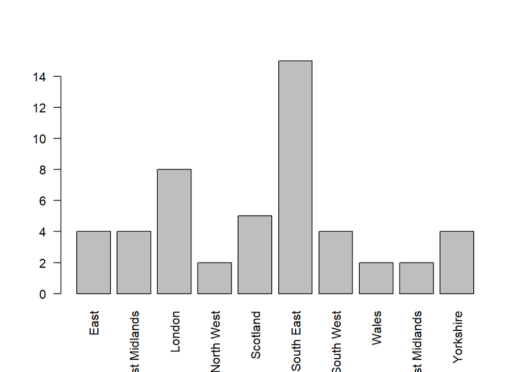

```r
par(mfrow=c(1,1))
par(las=2)
Regions = table(Decathletes_2022$Region)
barplot(Regions)
```

```r
chisq.test(Regions)$p.value
```

```
## [1] 0.0009538672
```

And we can see that the South East is miles ahead in terms of producing decathletes. From the chi squared test, we can see that this is statistically significant. However it’s also true that the South East has the greatest population, so we would expect this result. Lets scale these values according to their [population](https://en.wikipedia.org/wiki/Regions_of_England#List_of_regions).

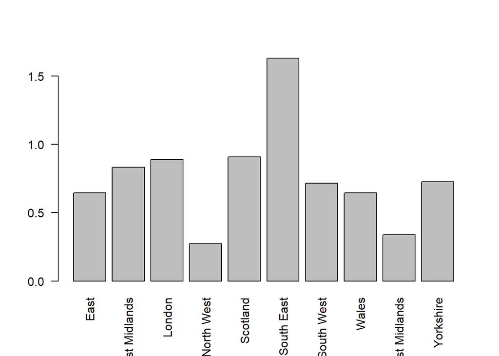

```r
#In millions
Populations = c(6.2,4.8,9,7.3,5.5,9.2,5.6,3.1,5.9,5.5)
adj_Regions = Regions/Populations
par(las=2)
barplot(adj_Regions)
```

```r
chisq.test(adj_Regions)
```

```
##
##  Chi-squared test for given probabilities
##
## data:  adj_Regions
## X-squared = 1.6366, df = 9, p-value = 0.996
```

Where still the South East is leading the pack, however the p-value indicates that this does not imply an unequal distribution of athletes. It’s likely that this is due to a small number of clubs, let’s check;

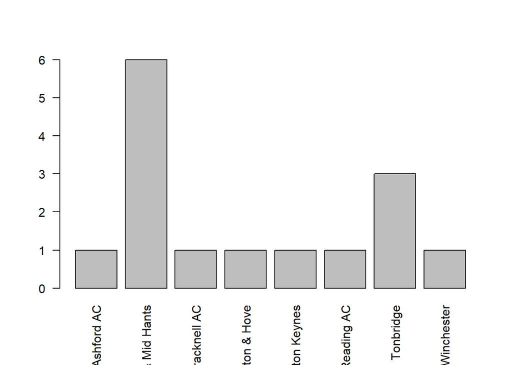

```r
par(las=2)
Decathletes_2022 |>  filter(Region=="South East") |>
                      dplyr::select(Club) |>
                      table() |>
                      barplot()
```

So Basingstoke & Mid Hants is the club to join for decathlon! We can see from [Power of 10](https://www.thepowerof10.info/rankings/rankinglist.aspx?event=Dec&agegroup=ALL&sex=M&year=2022) that these athletes (as well as a few others) are all coached by [Rafar Joseph](https://www.thepowerof10.info/athletes/profile.aspx?athleteid=26806). A more important question might perhaps be, which area produces the best decathletes? For this lets create a 2 dimensional table;

```r
Decathletes_2022$Groups = as.numeric(Decathletes_2022$Points) |>
                          cut(breaks=c(3000,6500,8000),
                              labels=c("Low","High"))
Grouped_Dec = table(Decathletes_2022$Groups, Decathletes_2022$Region)
Grouped_Dec
```

```
##
##        East East Midlands London North West Scotland South East South West
##   Low     4             4      4          1        3         10          2
##   High    0             0      4          1        2          5          2
##
##        Wales West Midlands Yorkshire
##   Low      1             1         3
##   High     1             1         1
```

Unfortunately we really don’t have enough data to test among every region, so instead lets combine categories and just check between north and south.

```r
South = Grouped_Dec[,1]+Grouped_Dec[,2]+Grouped_Dec[,3]+
        Grouped_Dec[,6]+Grouped_Dec[,7]+Grouped_Dec[,8]+Grouped_Dec[,9]
North = Grouped_Dec[,4]+Grouped_Dec[,5]+Grouped_Dec[,10]

Areas = cbind("North" = North, "South" =South)
dimnames(Areas) = list("Group"=c("Low","High"),"Region"=c("North","South"))
AdjAreas = Areas/c(sum(Populations[c(4,5,10)]),sum(Populations[c(4,5,10)]),
        sum(Populations[c(1,2,3,6,7,8,9)]),sum(Populations[c(1,2,3,6,7,8,9)]))

#Odds ratio
Areas[1]*Areas[4]/(Areas[2]*Areas[3])
```

```
## [1] 0.875
```

```r
step(loglm(~Region*Group,data=Areas),direction="backward", test="Chisq")
```

```
## Start:  AIC=8
## ~Region * Group
##
##                Df    AIC      LRT Pr(>Chi)
## - Region:Group  1 6.0348 0.034844   0.8519
## <none>            8.0000
##
## Step:  AIC=6.03
## ~Region + Group
##
##          Df     AIC     LRT  Pr(>Chi)
## <none>       6.0348
## - Group   1  9.2460  5.2112   0.02244 *
## - Region  1 20.6588 16.6239 4.557e-05 ***
## ---
## Signif. codes:  0 '***' 0.001 '**' 0.01 '*' 0.05 '.' 0.1 ' ' 1
```

```
## Call:
## loglm(formula = ~Region + Group, data = Areas, evaluate = FALSE)
##
## Statistics:
##                         X^2 df  P(> X^2)
## Likelihood Ratio 0.03484364  1 0.8519237
## Pearson          0.03511046  1 0.8513644
```

Here we see that AIC favours the independence model, which indicates that there isn’t a significant correlation between what side of the country you are on and whether you’re a good decathlete.

## Points Distribution

Another big question in decathlon is what events are the most important? Generally speaking, we can split the events in the decathlon into 4 categories; 3 sprints, 3 throws, 3 jumps and 1 endurance. Lets have a look at the points from 2022;

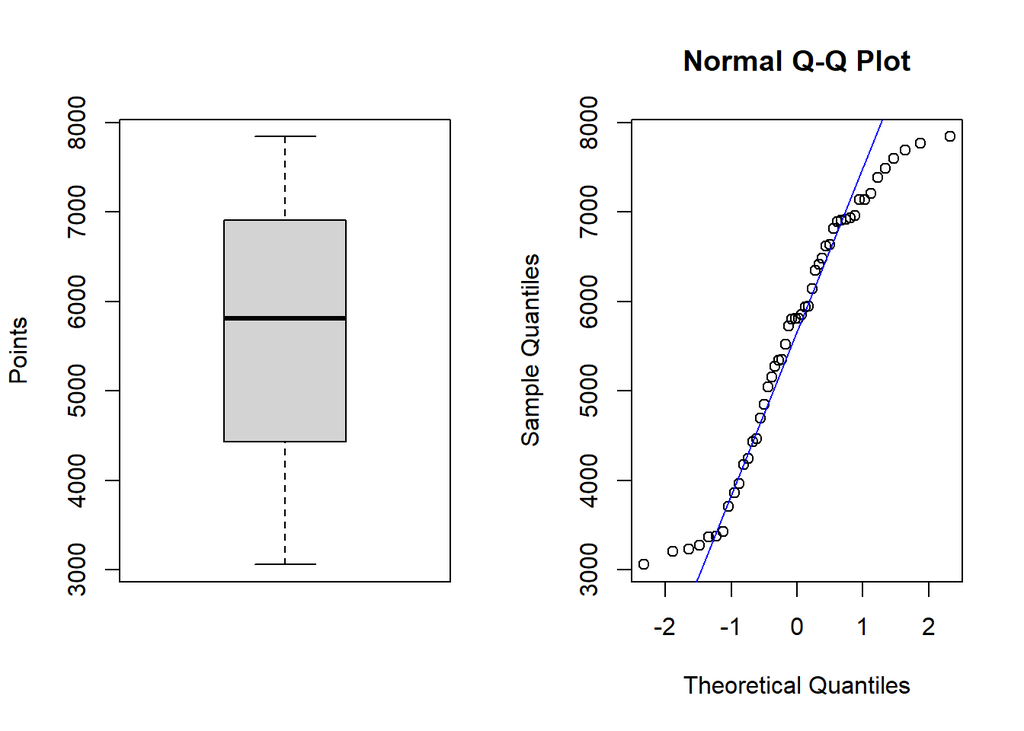

```r
par(mfrow=c(1,2))
boxplot(as.numeric(Decathletes_2022$Points), ylab="Points")
qqnorm(as.numeric(Decathletes_2022$Points))
qqline(as.numeric(Decathletes_2022$Points),col="blue")
```

We can see from the qq plot that we don’t have perfect normality, but that is to be expected from the small sample size and high variance of points.

We generally assume that an athletes tend to perform better in a certain group of events, for example an athlete may excel in the throws but fall behind in the 1500.

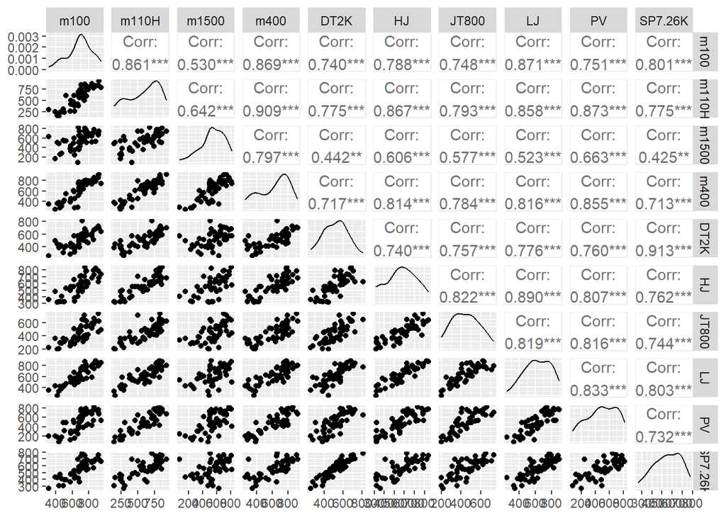

```r
Performances = data.frame("m100" = numeric(),"m110H"=numeric(),
                          "m1500" = numeric(), "m400" = numeric(),
                          "DT2K" = numeric(), "HJ" = numeric(),
                          "JT800" = numeric(), "LJ" = numeric(),
                          "PV" = numeric(), "SP7.26K"=numeric())

for(i in 1:nrow(Decathletes_2022)){
  Performances[i,] = get_decathlon_perf(Decathletes_2022$Links[i],2022)$points
}
ggpairs(Performances)
```

So we can see that, for example, discus and shot-put correlate very strongly (r=0.91) as do high and long jump (r=0.89) and hurdles and 400m (r=0.91). On the other hand, exactly as we would expect, we see that throws performance has a much weaker correlation with 1500m performances (r=0.44 with discus and 0.43 with shot-put).

Another interesting metric is the ratio of points. The issue with looking at raw points is that a good athlete tends to be better across the board, which nudges r values in the positive direction. By looking at the ratio of points achieved relative to total points, we can more accurately see if groups of events are correlated.

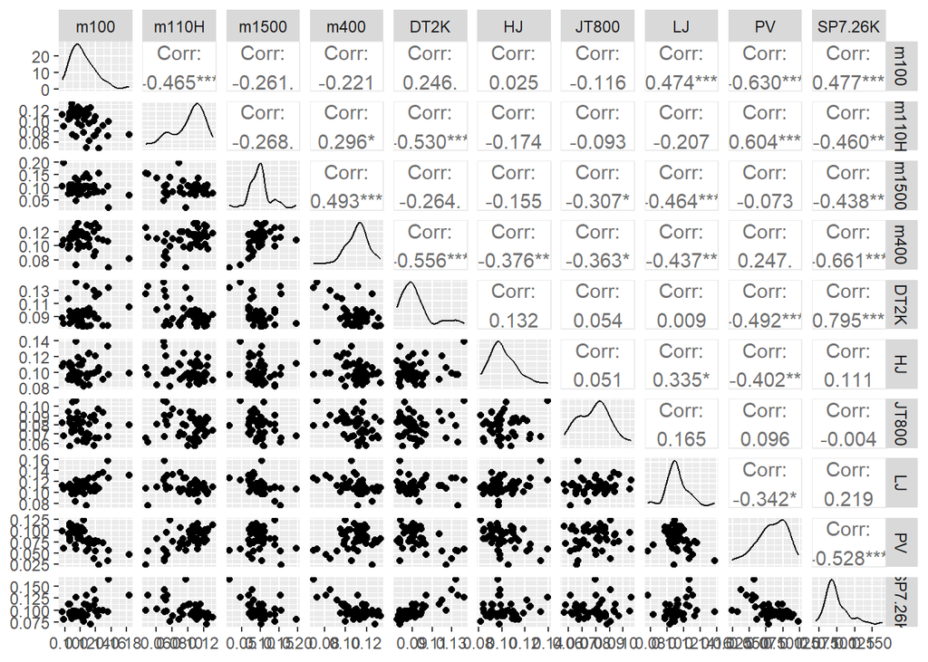

```r
PerformanceRatio = Performances
for (i in 1:nrow(PerformanceRatio)){
  PerformanceRatio[i,]=PerformanceRatio[i,]/sum(PerformanceRatio[i,])
}
ggpairs(PerformanceRatio)
```

This brings us onto another question, which events score the highest?

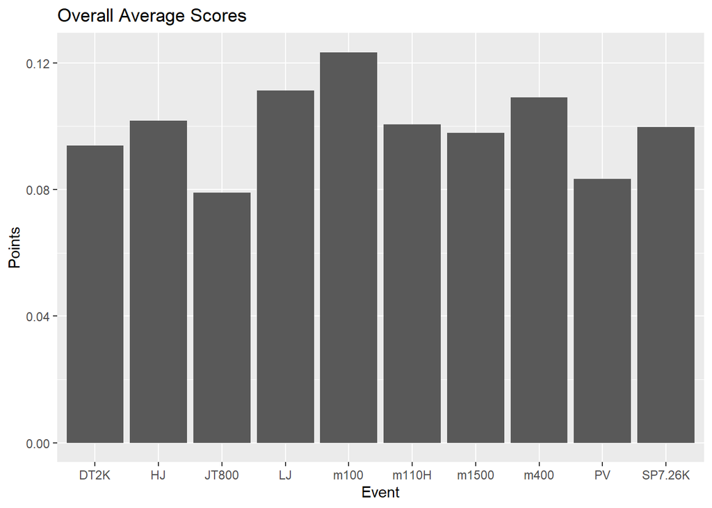

```r
Averages= colMeans(PerformanceRatio, na.rm=TRUE) |> data.frame() |> setNames(c("Points"))
Averages$Event = rownames(Averages)
ggplot(Averages, aes(x=Event, y=Points))+ggtitle("Overall Average Scores")+geom_col()
```

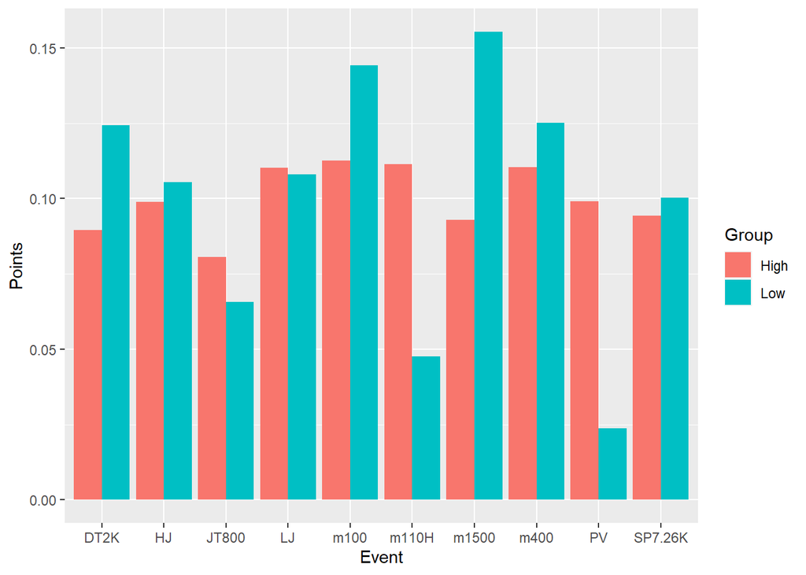

```r
AveragesLow= colMeans(PerformanceRatio[nrow(PerformanceRatio-20):nrow(PerformanceRatio),], na.rm=TRUE) |> data.frame() |> setNames(c("Points"))
AveragesHigh= colMeans(PerformanceRatio[1:20,], na.rm=TRUE) |> data.frame() |> setNames(c("Points"))
lowvhigh = cbind(AveragesLow,AveragesHigh) |> setNames(c("Low","High"))
lowvhigh$Event=rownames(Averages)
lowvhigh = lowvhigh |>
          pivot_longer(cols=c(1,2),names_to = "Group", values_to = "Points")
ggplot(lowvhigh, aes(fill=Group, y=Points, x=Event))+
  geom_bar(position="dodge",stat="identity")
```